# AI-Assisted Pipeline for Ants

# Q22: Does Anoplolepis gracilipes disperse as larvae or juvenile stages?

Answer: The provided context contains insufficient information to answer this question. None of the excerpts specifically address whether Anoplolepis gracilipes disperses as larvae or juvenile stages. The focus is primarily on adult dispersal strategies, such as budding and mating flights, without mention of larval or juvenile dispersal (Plentovich et al., 2011; Lenancker et al., 2019).  
References:  
- Lenancker, P., Feldhaar, H., Holzinger, A., Greenfield, M., Strain, A., Yeeles, P., Hoffmann, B. D., Tay, W. T., & Lach, L. (2021). Origin, behaviour, and genetics of reproductive workers in an invasive ant. Frontiers in Zoology. https://doi.org/10.1186/s12983-021-00392-2  
- Plentovich, S. M., Eijzenga, J., Eijzenga, H., & Smith, D. (2011). Indirect effects of ant eradication efforts on offshore islets in the Hawaiian archipelago. Biological Invasions, 13, 545-557. https://doi.org/10.1007/s10530-010-9848-y  
- Lenancker, P. (2019). Biological Processes Influencing the Success of Invasive Ants. PhD thesis, James Cook University. https://doi.org/10.25903/8zzn%2Djv28

# Q23: Is dispersal of Anoplolepis gracilipes density dependent?

Answer: The provided context contains insufficient information to definitively answer whether the dispersal of Anoplolepis gracilipes is density dependent. Some excerpts suggest that dispersal and ecological impacts are influenced by population density (Gruber et al., 2012; Hoffmann et al., 2014), while others indicate that environmental factors and anthropogenic disturbances play significant roles, potentially independent of density (Kaiser-Bunbury et al., 2014; Lee et al., 2021). Additionally, the presence of supercolonies and high densities on Christmas Island suggests that density may influence dispersal, but this is not explicitly confirmed (Abbott & Abbott, 2005).  
References:  
- Abbott, K. L., & Abbott, K. L. (2005). Supercolonies of the invasive yellow crazy ant, Anoplolepis gracilipes, on an oceanic island: forager activity patterns, density and biomass. Insectes Sociaux, 52(3), 266-273. https://doi.org/10.1007/s00040-005-0800-6  
- Gruber, M. A. M., Burne, A. R., Abbott, K. L., Pierce, R. J., & Lester, P. J. (2012). Population decline but increased distribution of an invasive ant genotype on a pacific atoll. Biological Invasions, 15(3), 599-612. https://doi.org/10.1007/s10530-012-0312-z  
- Hoffmann, B. D., Auina, S., & Stanley, M. C. (2014). Targeted research to improve invasive species management: yellow crazy ant Anoplolepis gracilipes in Samoa. PLoS ONE, 9(4), e95301. https://doi.org/10.1371/journal.pone.0095301  
- Kaiser-Bunbury, C., Cuthbert, H., Fox, R., Birch, D., & Bunbury, N. (2014). Invasion of yellow crazy ant Anoplolepis gracilipes in a Seychelles UNESCO palm forest. NeoBiota, 22, 43-57. https://doi.org/10.3897/neobiota.22.6634  
- Lee, C.-C., Chiu, M.-C., Shih, C.-H., Yang, C.-C. S., Liu, H.-C., & Lin, C.-C. (2021). The role of anthropogenic disturbance and invasion of yellow crazy ant in a recent decline of land crab population. Scientific Reports. https://doi.org/10.1038/s41598-021-91732-z

# Q24: Can Anoplolepis gracilipes withstand immersion in water for extended periods?

Answer: The provided context contains insufficient information to answer this question. None of the excerpts specifically address the ability of Anoplolepis gracilipes to withstand immersion in water for extended periods. The available information primarily discusses the ant’s habitat preferences, ecological impacts, and interactions with other species, but does not include details on their physiological tolerance to water immersion (Young et al., 2001; Marin & Tiunov, 2023; Lenancker, 2019; Stanley, 2004; Abbott & Abbott, 2005; Cooling & Hoffmann, 2015; Hoffmann et al., 2014; Kaiser-Bunbury et al., 2014; Lee et al., 2021).  
References:  
- Young, G.R., et al. (2001). The Crazy Ant Anoplolepis Gracilipes (Smith) (Hymenoptera: Formicidae) in East Arnhem Land, Australia. Australian Entomologist, 28(3), 97-104.  
- Marin, I. N., & Tiunov, A. V. (2023). Terrestrial crustaceans (arthropoda, crustacea): taxonomic diversity, terrestrial adaptations, and ecological functions. ZooKeys, 1169, 95-162. https://doi.org/10.3897/zookeys.1169.97812  
- Lenancker, P. (2019). Biological Processes Influencing the Success of Invasive Ants. PhD thesis, James Cook University. https://doi.org/10.25903/8zzn%2Djv28  
- Stanley, M. C. (2004). Review of the Efficacy of Baits Used for Ant Control and Eradication. Landcare Research Contract Report: LC0405/044, Landcare Research New Zealand Ltd.  
- Abbott, K. L., & Abbott, K. L. (2005). Supercolonies of the invasive yellow crazy ant, Anoplolepis gracilipes, on an oceanic island: forager activity patterns, density and biomass. Insectes Sociaux, 52, 266-273. https://doi.org/10.1007/s00040-005-0800-6  
- Cooling, M., & Hoffmann, B. D. (2015). Here today, gone tomorrow: declines and local extinctions of invasive ant populations in the absence of intervention. Biological Invasions, 17, 3351-3357. https://doi.org/10.1007/s10530-015-0963-7  
- Hoffmann, B. D., Auina, S., & Stanley, M. C. (2014). Targeted research to improve invasive species management: yellow crazy ant Anoplolepis gracilipes in Samoa. PLoS ONE, 9, e95301. https://doi.org/10.1371/journal.pone.0095301  
- Kaiser-Bunbury, C., Cuthbert, H., Fox, R., Birch, D., & Bunbury, N. (2014). Invasion of yellow crazy ant Anoplolepis gracilipes in a Seychelles UNESCO palm forest. NeoBiota, 22, 43-57. https://doi.org/10.3897/neobiota.22.6634  
- Lee, C.-C., Chiu, M.-C., Shih, C.-H., Yang, C.-C. S., Liu, H.-C., & Lin, C.-C. (2021). The role of anthropogenic disturbance and invasion of yellow crazy ant in a recent decline of land crab population. Scientific Reports. https://doi.org/10.1038/s41598-021-91732-z

# Q25: Is Anoplolepis gracilipes predated upon by other species?

Answer: The provided context contains insufficient information to answer this question. None of the excerpts explicitly mention Anoplolepis gracilipes being predated upon by other species. The focus is primarily on the ant’s competitive interactions, its impact on other species, and its role as an invasive species, rather than its own predation by other organisms (McNatty et al., 2009; Lee et al., 2021; Abbott et al., 2007; Hill et al., 2003; Kaiser-Bunbury et al., 2014; Plentovich et al., 2011; Cooling & Hoffmann, 2015; Gil-Hoed et al., 2025; Hoffmann & Saul, 2010; Hoffmann et al., 2014).  
References:  
- Abbott, K. L., Greaves, S. N. J., Ritchie, P., & Lester, P. J. (2007). Behaviourally and genetically distinct populations of an invasive ant provide insight into invasion history and impacts on a tropical ant community. Biological Invasions, 9(3), 453-463. https://doi.org/10.1007/s10530-006-9052-2  
- Cooling, M., & Hoffmann, B. D. (2015). Here today, gone tomorrow: declines and local extinctions of invasive ant populations in the absence of intervention. Biological Invasions, 17(12), 3351-3357. https://doi.org/10.1007/s10530-015-0963-7  
- Gil-Hoed, C., Foitzik, S., & Jaimes-Nino, L. M. (2025). Well-coordinated cooperative transport in the invasive ant anoplolepis gracilipes. Insectes Sociaux, 72(4), 475-486. https://doi.org/10.1007/s00040-025-01027-z  
- Hill, M., Holm, K., Vel, T., Shah, N. J., & Matyot, P. (2003). Impact of the introduced yellow crazy ant anoplolepis gracilipes on bird island, seychelles. Biodiversity & Conservation, 12(9), 1969-1984. https://doi.org/10.1023/a:1024151630204  
- Hoffmann, B. D., & Saul, W.-C. (2010). Yellow crazy ant (anoplolepis gracilipes) invasions within undisturbed mainland australian habitats: no support for biotic resistance hypothesis. Biological Invasions, 12(10), 3093-3108. https://doi.org/10.1007/s10530-010-9701-3  
- Hoffmann, B. D., Auina, S., & Stanley, M. C. (2014). Targeted research to improve invasive species management: yellow crazy ant anoplolepis gracilipes in samoa. PLoS ONE, 9(4), e95301. https://doi.org/10.1371/journal.pone.0095301  
- Kaiser-Bunbury, C., Cuthbert, H., Fox, R., Birch, D., & Bunbury, N. (2014). Invasion of yellow crazy ant anoplolepis gracilipes in a seychelles unesco palm forest. NeoBiota, 22, 43-57. https://doi.org/10.3897/neobiota.22.6634  
- Lee, C.-C., Chiu, M.-C., Shih, C.-H., Yang, C.-C. S., Liu, H.-C., & Lin, C.-C. (2021). The role of anthropogenic disturbance and invasion of yellow crazy ant in a recent decline of land crab population. Scientific Reports. https://doi.org/10.1038/s41598-021-91732-z  
- McNatty, A., Abbott, K. L., & Lester, P. J. (2009). Invasive ants compete with and modify the trophic ecology of hermit crabs on tropical islands. Oecologia, 160(1), 187-194. https://doi.org/10.1007/s00442-009-1279-z  
- Plentovich, S. M., Eijzenga, J., Eijzenga, H., & Smith, D. (2011). Indirect effects of ant eradication efforts on offshore islets in the hawaiian archipelago. Biological Invasions, 13(3), 545-557. https://doi.org/10.1007/s10530-010-9848-y

## Step 3: Complete Report using GPT-Researcher

- Deep research (GPT-Researcher) on known interactions
- Focus: establishment, climate, impact
- Produce 1-2 pages with references

More information: github.com/assafelovic/gpt-researcher

## GPT-Researcher workflow

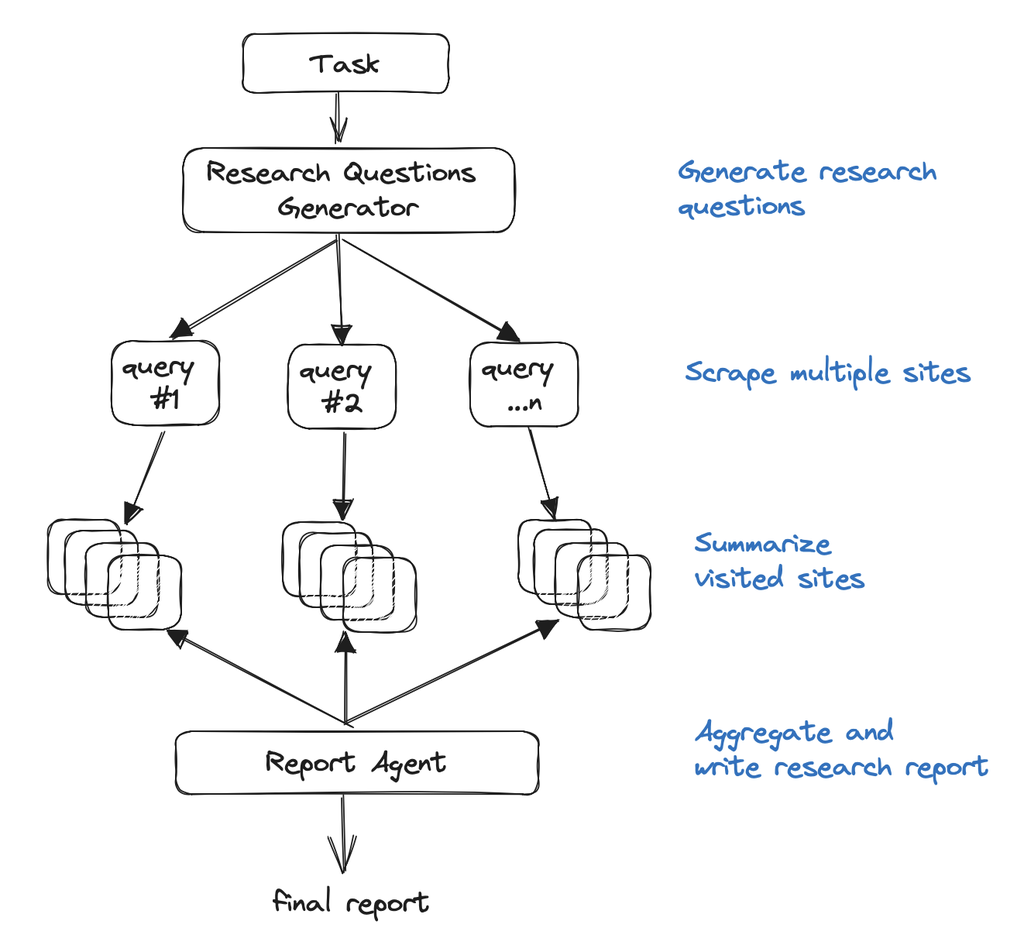

## GPT-Researcher example: Anoplolepis gracilipes

[interactive chart not shown]